# 성평등의 역설

Hanbin Lee

2019년 3월 16일

- 이 문서는 Rmarkdown을 사용하여 작성됐습니다.

# 성평등의 역설: 생태적 오류는 어떻게 발생하는가?

*성평등의 역설*은 페이스북의 [게시물](https://www.facebook.com/permalink.php?story_fbid=730109564057610&id=303765500025354)에서 보셨듯이 아무런 의미가 없는 현상입니다. 오래전부터 통계학에서 유명했던 생태적 오류(Ecologic Fallacy)의 전형일 뿐입니다. 생태적 오류에 대해서는 이전에 [Lippa (2009)](https://hanbin973.github.io/lippa/main.html)를 논하면서 다룬 바 있습니다. 이전에는 데이터 마사지를 통해 통계적 유의성을 얻는 과정을 보여드렸다면 오늘은 좀 더 직관적인 그림과 예제를 통해 이를 다시 확인하겠습니다.

가상의 5개 국가 A~E를 가정하고 국가 안에서는 교육수준이 높아질수록 소득이 높아짐에도 불구하고 국가간 비교에서 교육수준이 높아질수록 소득이 감소하는 상황을 만들어보겠습니다.

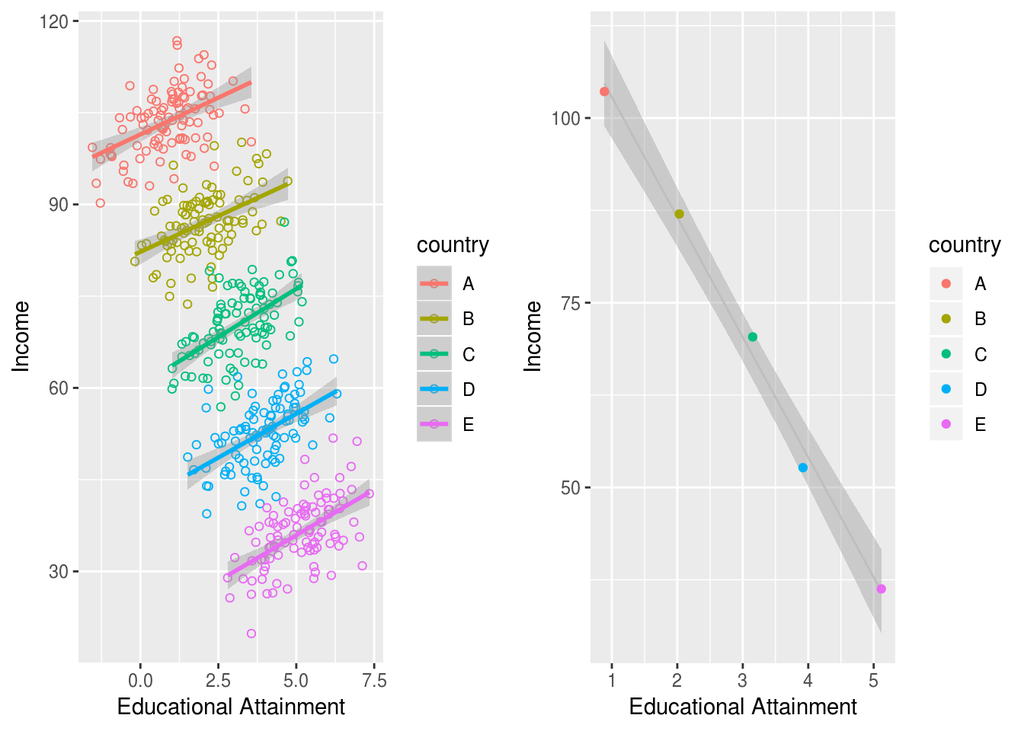

좌측 그림은 각 국가별(색깔로 구분)로 교육수준(Educational Attainment)에 따른 소득수준(Income)을 나타낸 것입니다. 그림에서 볼 수 있듯이 각 국가 안에서는 교육수준이 증가할수록 소득수준이 증가하는 것을 관찰할 수 있습니다.

우측 그림은 교육수준과 소득수준을 평균 낸 뒤 그래프를 그린 것입니다. 좌측 그림과는 다르게 교육수준이 증가할수록 소득수준이 감소하는 것을 관찰할 수 있습니다.

좌측 그림과 우측 그림 중 무엇이 더 정확할까요? 당연히 좌측 그림이 더 정확합니다. 우측 그림은 좌측 그림을 그리는데 사용한 데이터를 평균내서 필요한 정보들이 소실된 결과물이기 때문이죠. 이래서 국가간 평균값을 비교하는 것은 국가 안의 개인의 정보를 추정하는데 도움이 되지 않습니다. 그리고 이러한 정보소실을 이용해 거짓된 사실을 선동하는 사람들이 ‘성평등의 역설’ 이라니 ‘백신은 자폐를 유발’ 한다드니 떠들고 다니는 것이지요.

Gordis (2013) 를 참고하였습니다

## 참고문헌

Gordis, Leon. 2013. *Epidemiology: With Student Consult Online Access (Gordis, Epidemiology)*. Saunders. https://www.amazon.com/Epidemiology-STUDENT-CONSULT-Online-Access/dp/145573733X?SubscriptionId=AKIAIOBINVZYXZQZ2U3A&tag=chimbori05-20&linkCode=xm2&camp=2025&creative=165953&creativeASIN=145573733X.